# Classification Project (Sri)

by Srinidhi (Sri) Manikantan

### 1) Loading and Viewing the Dataset

We will start off with loading the dataset that was provided to us. We will be using the head() function to briefly look through the dataset and get a sensing of what we are dealing with. head() will show the first few rows of the dataset

```r
df <- read.csv("kepler2.csv", stringsAsFactors=TRUE)
head(df)
```

```
##      period impact duration  depth      ror    srho  prad  incl  teq    dor
## 1  9.488036  0.146  2.95750  615.8 0.022344 3.20796  2.26 89.66  793 24.810
## 2 54.418383  0.586  4.50700  874.8 0.027954 3.02368  2.83 89.57  443 77.900
## 3  1.736952  1.276  2.40641 8079.2 0.387394 0.22080 33.46 67.09 1395  3.278
## 4  2.525592  0.701  1.65450  603.3 0.024064 1.98635  2.75 85.41 1406  8.750
## 5 11.094321  0.538  4.59450 1517.5 0.036779 0.67324  3.90 88.11  835 16.360
## 6  4.134435  0.762  3.14020  686.0 0.026133 0.37377  2.77 83.72 1160  6.960
##   steff slogg  smet  srad smass          label
## 1  5455 4.467  0.14 0.927 0.919      CONFIRMED
## 2  5455 4.467  0.14 0.927 0.919      CONFIRMED
## 3  5805 4.564 -0.52 0.791 0.836 FALSE POSITIVE
## 4  6031 4.438  0.07 1.046 1.095      CONFIRMED
## 5  6046 4.486 -0.08 0.972 1.053      CONFIRMED
## 6  6046 4.486 -0.08 0.972 1.053      CONFIRMED
```

### 2) Basic information about the dataset

First, we will start off by finding the number of rows and columns of our dataset. From the output below, we can see that there are **6859 rows and 16 columns.**

```r
dim(df)
```

```
## [1] 6859   16
```

Let’s find out more details about the individual columns in the dataset (e.g. the **summary statistics, type of variables** etc. )

```r
str(df)
```

```
## 'data.frame':    6859 obs. of  16 variables:
##  $ period  : num  9.49 54.42 1.74 2.53 11.09 ...
##  $ impact  : num  0.146 0.586 1.276 0.701 0.538 ...
##  $ duration: num  2.96 4.51 2.41 1.65 4.59 ...
##  $ depth   : num  616 875 8079 603 1518 ...
##  $ ror     : num  0.0223 0.028 0.3874 0.0241 0.0368 ...
##  $ srho    : num  3.208 3.024 0.221 1.986 0.673 ...
##  $ prad    : num  2.26 2.83 33.46 2.75 3.9 ...
##  $ incl    : num  89.7 89.6 67.1 85.4 88.1 ...
##  $ teq     : int  793 443 1395 1406 835 1160 1360 1342 600 1339 ...
##  $ dor     : num  24.81 77.9 3.28 8.75 16.36 ...
##  $ steff   : int  5455 5455 5805 6031 6046 6046 6046 6227 5031 5820 ...
##  $ slogg   : num  4.47 4.47 4.56 4.44 4.49 ...
##  $ smet    : num  0.14 0.14 -0.52 0.07 -0.08 -0.08 -0.08 0 0.16 -0.06 ...
##  $ srad    : num  0.927 0.927 0.791 1.046 0.972 ...
##  $ smass   : num  0.919 0.919 0.836 1.095 1.053 ...
##  $ label   : Factor w/ 2 levels "CONFIRMED","FALSE POSITIVE": 1 1 2 1 1 1 1 2 1 1 ...
```

```r
summary(df)
```

```
##      period              impact            duration            depth
##  Min.   :   0.2418   Min.   :  0.0000   Min.   :  0.1046   Min.   :      0.8
##  1st Qu.:   2.1132   1st Qu.:  0.2330   1st Qu.:  2.5379   1st Qu.:    181.9
##  Median :   7.4427   Median :  0.5920   Median :  3.9085   Median :    512.6
##  Mean   :  50.8026   Mean   :  0.7632   Mean   :  5.8514   Mean   :  31492.3
##  3rd Qu.:  27.5014   3rd Qu.:  0.9220   3rd Qu.:  6.3490   3rd Qu.:   3031.6
##  Max.   :1071.2326   Max.   :100.8060   Max.   :138.5400   Max.   :1541400.0
##       ror                srho               prad                incl
##  Min.   : 0.00129   Min.   :  0.0000   Min.   :     0.08   Min.   : 2.29
##  1st Qu.: 0.01320   1st Qu.:  0.1777   1st Qu.:     1.51   1st Qu.:81.37
##  Median : 0.02453   Median :  0.7595   Median :     2.71   Median :87.89
##  Mean   : 0.30180   Mean   :  6.9371   Mean   :   109.93   Mean   :80.81
##  3rd Qu.: 0.21976   3rd Qu.:  2.3885   3rd Qu.:    26.82   3rd Qu.:89.62
##  Max.   :99.87065   Max.   :980.8542   Max.   :200346.00   Max.   :90.00
##       teq               dor               steff           slogg
##  Min.   :   92.0   Min.   :   0.386   Min.   : 2661   Min.   :0.047
##  1st Qu.:  583.5   1st Qu.:   4.053   1st Qu.: 5325   1st Qu.:4.204
##  Median :  955.0   Median :  12.220   Median : 5780   Median :4.438
##  Mean   : 1177.7   Mean   :  55.334   Mean   : 5730   Mean   :4.304
##  3rd Qu.: 1531.0   3rd Qu.:  34.700   3rd Qu.: 6130   3rd Qu.:4.542
##  Max.   :14667.0   Max.   :2421.700   Max.   :15896   Max.   :5.283
##       smet              srad             smass                  label
##  Min.   :-2.5000   Min.   :  0.116   Min.   :0.094   CONFIRMED     :2296
##  1st Qu.:-0.2800   1st Qu.:  0.830   1st Qu.:0.844   FALSE POSITIVE:4563
##  Median :-0.1000   Median :  1.000   Median :0.974
##  Mean   :-0.1357   Mean   :  1.775   Mean   :1.029
##  3rd Qu.: 0.0600   3rd Qu.:  1.368   3rd Qu.:1.104
##  Max.   : 0.5600   Max.   :229.908   Max.   :3.686
```

### 3) Cleaning/Processing the dataset

First, we will be checking to see if our dataset has any missing data and remove any rows that have any.

```r
sapply(df, function(x) sum(is.na(x)))
```

```
##   period   impact duration    depth      ror     srho     prad     incl
##        0        0        0        0        0        0        0        0
##      teq      dor    steff    slogg     smet     srad    smass    label
##        0        0        0        0        0        0        0        0
```

```r
w <- complete.cases(df)
df1 <- df[w,]

dim(df) - dim(df1)
```

```
## [1] 0 0
```

```r
low_variance_cols <- names(df)[apply(df, 2, var) == 0]
low_variance_cols
```

```
## [1] NA
```

```r
unique_counts <- sapply(df, function(column) length(unique(column)))
print(unique_counts)
```

```
##   period   impact duration    depth      ror     srho     prad     incl
##     6859     1960     6193     5763     6558     6686     2761     2144
##      teq      dor    steff    slogg     smet     srad    smass    label
##     2420     5117     2233     1410      116     2037     1362        2
```

This also shows that all our columns have distinct values, and could possibly be meaningful for analysis. Hence, **we will NOT be dropping any predictor variables from our dataset.**

### 3) Analysis distribution of predictor variables and identifying outliers (if any)

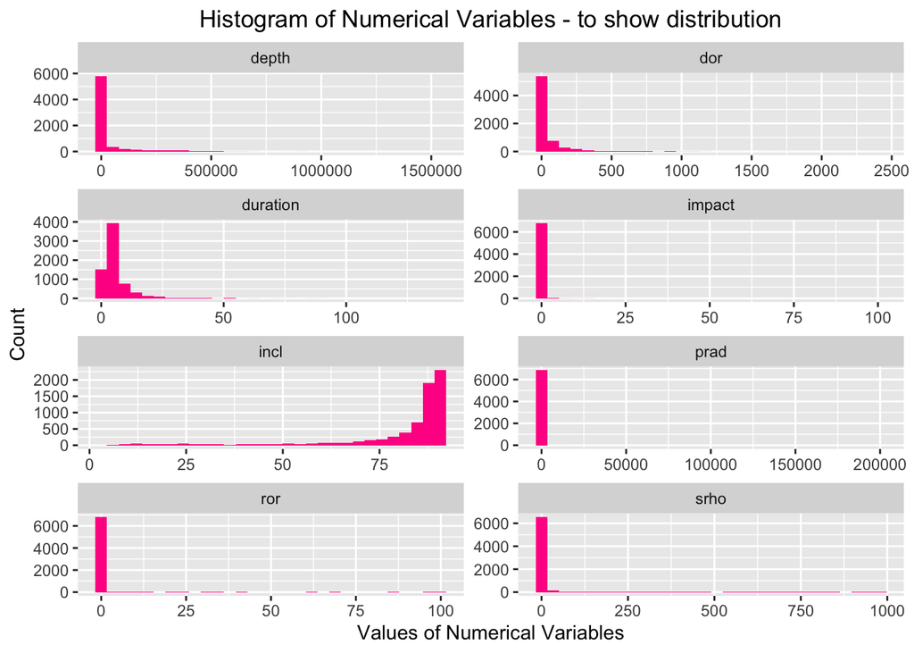

```r
df %>%
  select(depth, dor, duration, impact, ror,srho,prad,incl) %>%
  gather(key="Variables", value = "Value") %>%
  ggplot(., aes(x=Value)) +
  facet_wrap(~ Variables , ncol = 2, scales= "free") +
  geom_histogram(fill="deeppink") +
  ggtitle("Histogram of Numerical Variables - to show distribution") +
  theme(plot.title = element_text(hjust = 0.5)) +
  labs(x = "Values of Numerical Variables", y="Count")
```

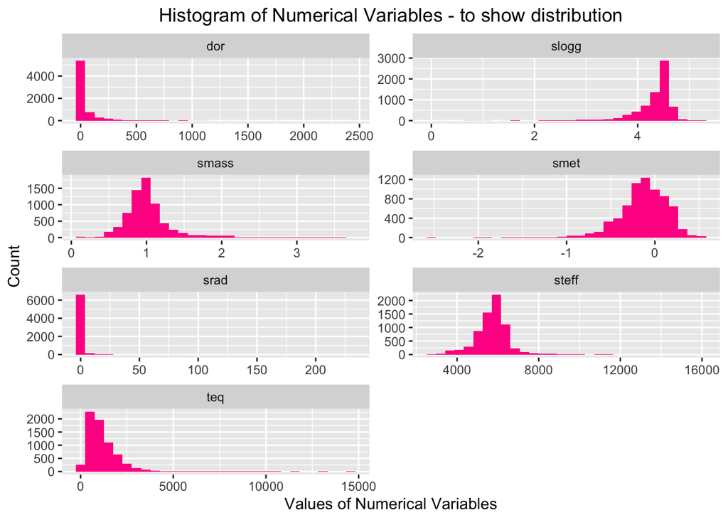

```r
df %>%
  select(teq, dor, steff, slogg, smet, srad, smass) %>%
  gather(key="Variables", value = "Value") %>%
  ggplot(., aes(x=Value)) +
  facet_wrap(~ Variables , ncol = 2, scales= "free") +
  geom_histogram(fill="deeppink") +
  ggtitle("Histogram of Numerical Variables - to show distribution") +
  theme(plot.title = element_text(hjust = 0.5)) +
  labs(x = "Values of Numerical Variables", y="Count")
```

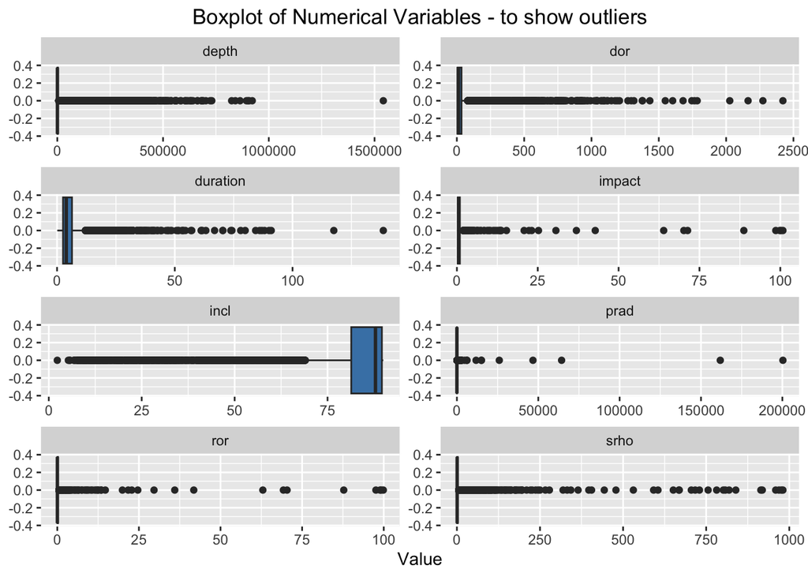

```r
df %>%
  select(depth, dor, duration, impact, ror,srho,prad,incl) %>%
  gather(key="Variables", value = "Value") %>%
  ggplot(., aes(x=Value)) +
  facet_wrap(~ Variables , ncol = 2, scales= "free") +
  geom_boxplot(fill="steelblue") +
  ggtitle("Boxplot of Numerical Variables - to show outliers") +
  theme(plot.title = element_text(hjust = 0.5))
```

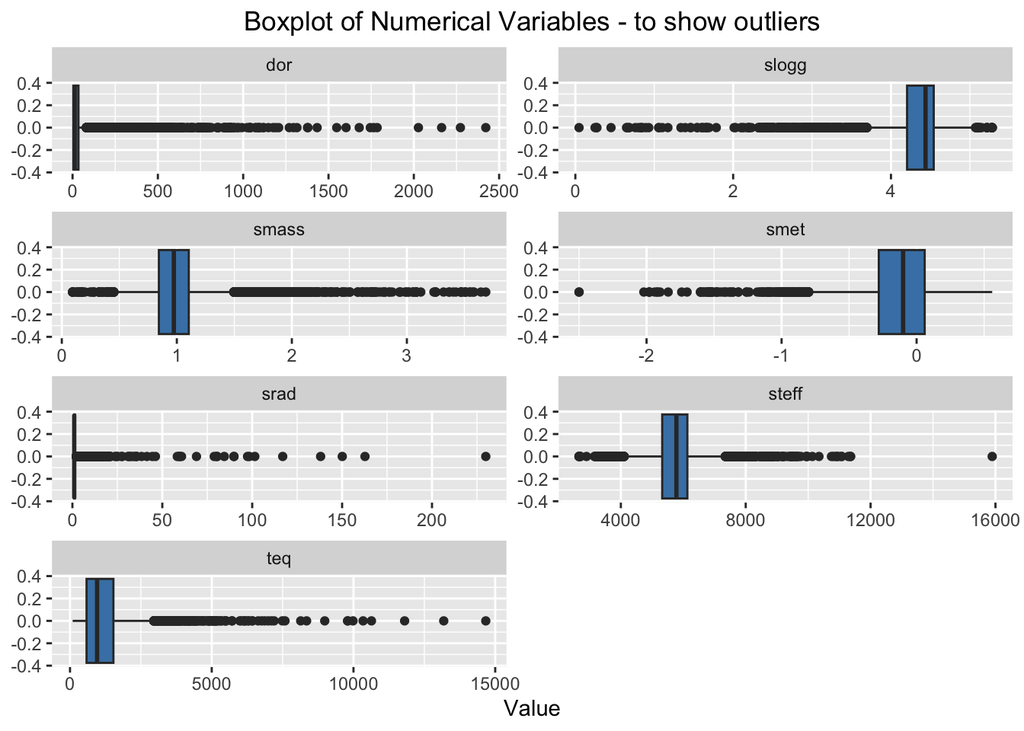

```r
df %>%
  select(teq, dor, steff, slogg, smet, srad, smass) %>%
  gather(key="Variables", value = "Value") %>%
  ggplot(., aes(x=Value)) +
  facet_wrap(~ Variables , ncol = 2, scales= "free") +
  geom_boxplot(fill="steelblue") +
  ggtitle("Boxplot of Numerical Variables - to show outliers") +
  theme(plot.title = element_text(hjust = 0.5))
```

From the above analysis, we can see that there could be some potential outliers in our dataset, especially for variables “depth”, “prad” and “steff”. We are going to use z-score to confirm if there are any significant outliers.

When we set the threshold to 10, we can see that z-score did pick up 6 outliers from these 3 variables. **We will be removing these from our dataset, as they may significantly affect our analysis.**

```r
z_depth <- scale(df$depth)
z_prad <- scale(df$prad)
z_steff <- scale(df$steff)

#to define a threshold for outlier
threshold <- 10

#to count the number of outliers for each variable
num_outliers_depth <- sum(abs(z_depth) > threshold)
num_outliers_prad <- sum(abs(z_prad) > threshold)
num_outliers_steff <- sum(abs(z_steff) > threshold)

num_outliers_depth
```

```
## [1] 1
```

```r
num_outliers_prad
```

```
## [1] 4
```

```r
num_outliers_steff
```

```
## [1] 1
```

```r
df <- df[order(-df$depth), ]
head(df$depth)
```

```
## [1] 1541400  921670  907420  901660  894200  864260
```

```r
df <- df[df$depth != 1541400, , drop = FALSE]
```

```r
df <- df[order(-df$prad), ]
head(df$prad)
```

```
## [1] 200346.0 161858.0  64333.8  46743.4  26042.9  15056.9
```

```r
df <- df[df$prad != 200346.0, , drop = FALSE]
df <- df[df$prad != 161858.0, , drop = FALSE]
df <- df[df$prad != 64333.8, , drop = FALSE]
df <- df[df$prad != 46743.4, , drop = FALSE]
```

```r
df <- df[order(-df$steff), ]
head(df$steff)
```

```
## [1] 15896 11360 11357 11287 11076 11068
```

```r
df <- df[df$steff != 15896, , drop = FALSE]
```

```r
dim(df)
```

```
## [1] 6853   16
```

From the above output, we can see that the 6 outliers have been removed from our dataset.

### 4) Splitting the data into training and test sets for classification

```r
response   <- df[,16]
predictors <- data.frame(scale(df[,-16]))
```

```r
set.seed(404)
s <- sample(nrow(predictors),0.7*nrow(predictors))
pred.train = predictors[s,]
pred.test = predictors[-s,]

resp.train = response[s]
resp.test = response[-s]
```

### 5) Analyzing with Logistic Regression Model

```r
out.log = glm(resp.train~.,family=binomial,data=pred.train)
resp.prob = predict(out.log,newdata=pred.test,type="response")
resp.pred = ifelse(resp.prob>0.5,"FALSE POSITIVE", "CONFIRMED")

MCR_log = mean(resp.pred!=resp.test)
CM_log = table(resp.pred,resp.test)

MCR_log
```

```
## [1] 0.1298638
```

```r
CM_log
```

```
##                 resp.test
## resp.pred        CONFIRMED FALSE POSITIVE
##   CONFIRMED            594            164
##   FALSE POSITIVE       103           1195
```

#### Determining the null classification rate (i.e. if we simply guess that all data belong to the majority class)

```r
prop_fail = sum(resp.test=="FALSE POSITIVE")/length(resp.test)

1-prop_fail
```

```
## [1] 0.3390078
```

```r
((1 - prop_fail - 0.12) / 0.12) * 100
```

```
## [1] 182.5065
```

The null MCR is much higher than the MCR rate that we got for our logistic regression model above. Our logistic regression does about 180% better than the null rate in terms of misclassification rate.

```r
roc.log = roc(resp.test,resp.prob)
```

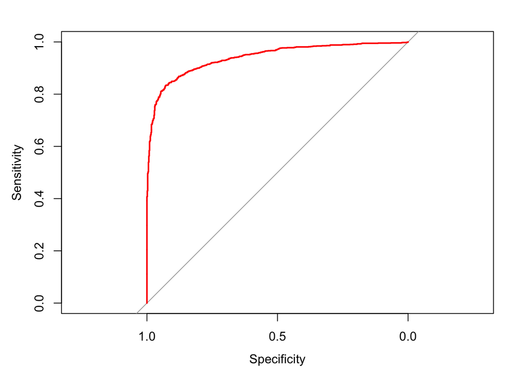

```r
plot(roc.log,col="red",xlim=c(1,0),ylim=c(0,1))
```

```r
AUC_log = round(roc.log$auc,4)
AUC_log
```

```
## [1] 0.94
```

```r
out.log = glm(resp.train~.,family=binomial,data=pred.train)
resp.prob.log = predict(out.log,newdata=pred.test,type="response")
resp.pred = ifelse(resp.prob>0.6494639,"FALSE POSITIVE", "CONFIRMED")

MCR_log1 = mean(resp.pred!=resp.test)
CM_log1 = table(resp.pred,resp.test)

MCR_log1
```

```
## [1] 0.1366732
```

```r
CM_log1
```

```
##                 resp.test
## resp.pred        CONFIRMED FALSE POSITIVE
##   CONFIRMED            641            225
##   FALSE POSITIVE        56           1134
```

```r
roc.log = roc(resp.test,resp.prob.log)
```

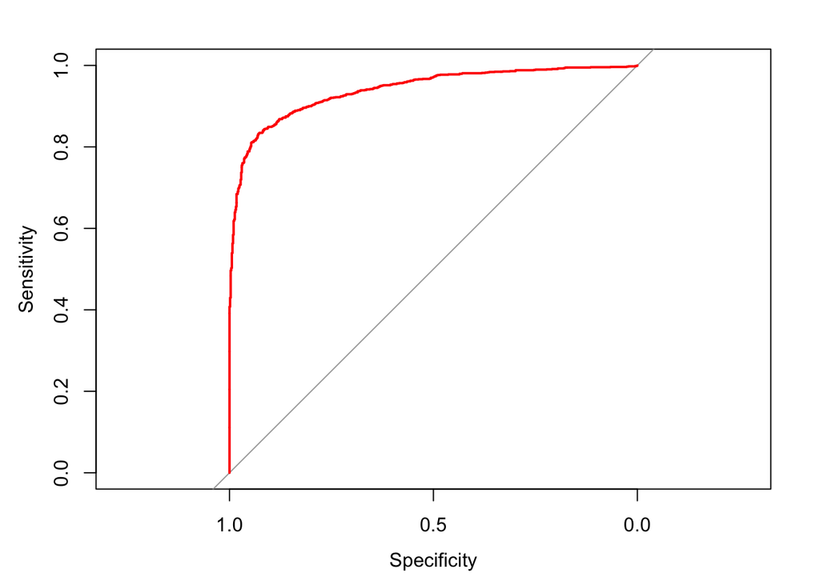

```r
plot(roc.log,col="red",xlim=c(1,0),ylim=c(0,1))
```

```r
AUC1_log = round(roc.log$auc,4)
AUC1_log
```

```
## [1] 0.94
```

### 6) Analyzing with Regression Tree Model

```r
rpart.out <- rpart(resp.train~. , data = pred.train, method = "class")
resp.pred = predict(rpart.out, newdata = pred.test, type="class")

MCR_tree = mean(resp.pred!=resp.test)
CM_tree = table(resp.pred,resp.test)

MCR_tree
```

```
## [1] 0.1274319
```

```r
CM_tree
```

```
##                 resp.test
## resp.pred        CONFIRMED FALSE POSITIVE
##   CONFIRMED            572            137
##   FALSE POSITIVE       125           1222
```

```r
resp.pred.tree <- predict(rpart.out,newdata=pred.test,type="prob")[,2]
(roc.tree = roc(resp.test,resp.pred.tree))
```

```
##
## Call:
## roc.default(response = resp.test, predictor = resp.pred.tree)
##
## Data: resp.pred.tree in 697 controls (resp.test CONFIRMED) < 1359 cases (resp.test FALSE POSITIVE).
## Area under the curve: 0.9134
```

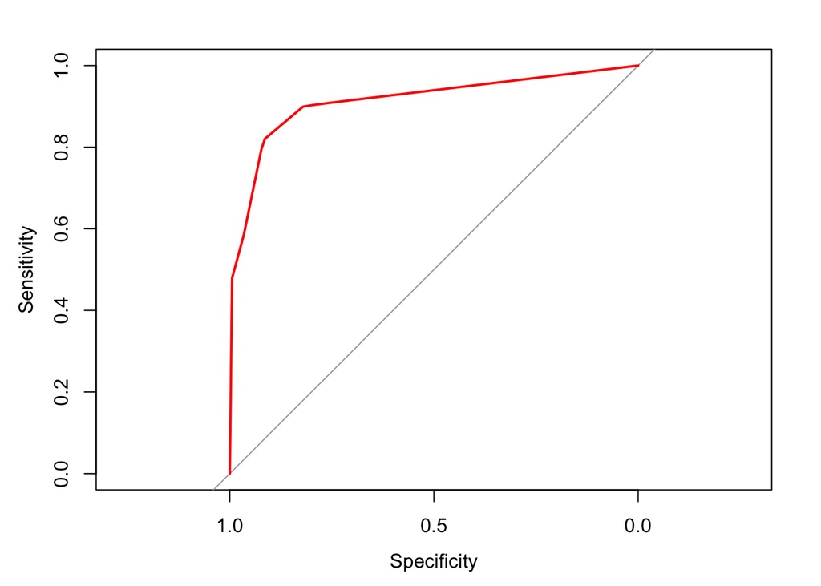

```r
plot(roc.tree,col="red",xlim=c(1,0),ylim=c(0,1))
```

```r
AUC_tree = round(roc.tree$auc,4)
AUC_tree
```

```
## [1] 0.9134
```

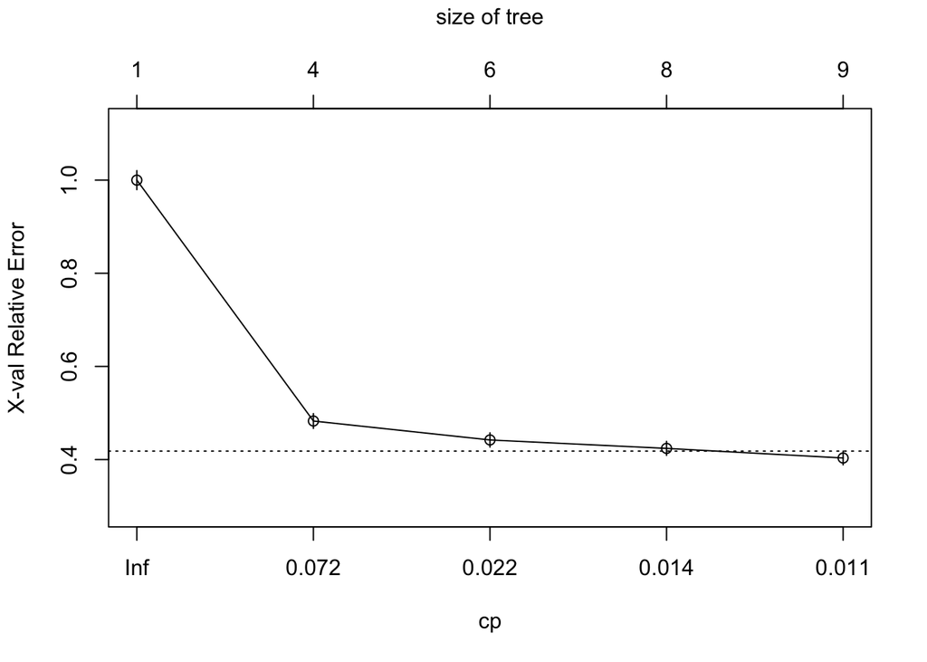

```r
plotcp(rpart.out)
```

From the output above, we can see that the leftmost point that lies below the dotted line is the last point farthest to the right, therefore pruning is not necessary in this case.

### 7) Analyzing with Random Forest Model

```r
set.seed(404)
rf.out = randomForest(resp.train~.,data=pred.train,importance=TRUE)
out.pred = predict(rf.out,newdata=pred.test,type="prob")[,2]
resp.pred = factor(ifelse(out.pred>0.5,"FALSE POSITIVE","CONFIRMED"),levels=c("FALSE POSITIVE","CONFIRMED"))

MCR_forest = mean(resp.pred!=resp.test)
CM_forest = table(resp.pred,resp.test)

MCR_forest
```

```
## [1] 0.08803502
```

```r
CM_forest
```

```
##                 resp.test
## resp.pred        CONFIRMED FALSE POSITIVE
##   FALSE POSITIVE        73           1251
##   CONFIRMED            624            108
```

```r
roc.forest = roc(resp.test,out.pred)
```

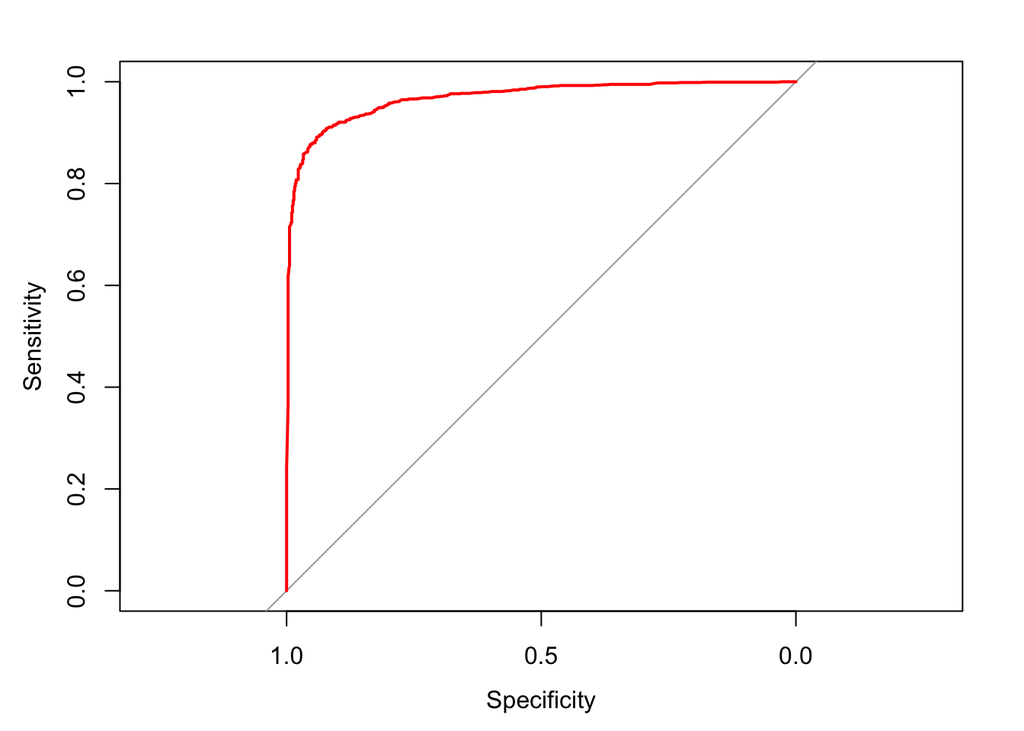

```r
plot(roc.forest,col="red",xlim=c(1,0),ylim=c(0,1))
```

```r
AUC_forest = round(roc.forest$auc,4)
AUC_forest
```

```
## [1] 0.9686
```

```r
optimal_threshold.forest <- coords(roc.forest, "best")$threshold
optimal_threshold.forest
```

```
## [1] 0.625
```

```r
set.seed(404)
rf.out = randomForest(resp.train~.,data=pred.train,importance=TRUE)
out.pred = predict(rf.out,newdata=pred.test,type="prob")[,2]
resp.pred = factor(ifelse(out.pred>0.662,"FALSE POSITIVE","CONFIRMED"),levels=c("FALSE POSITIVE","CONFIRMED"))

MCR1_forest = mean(resp.pred!=resp.test)
CM1_forest = table(resp.pred,resp.test)

MCR1_forest
```

```
## [1] 0.09776265
```

```r
CM1_forest
```

```
##                 resp.test
## resp.pred        CONFIRMED FALSE POSITIVE
##   FALSE POSITIVE        35           1193
##   CONFIRMED            662            166
```

```r
roc.forest = roc(resp.test,out.pred)
```

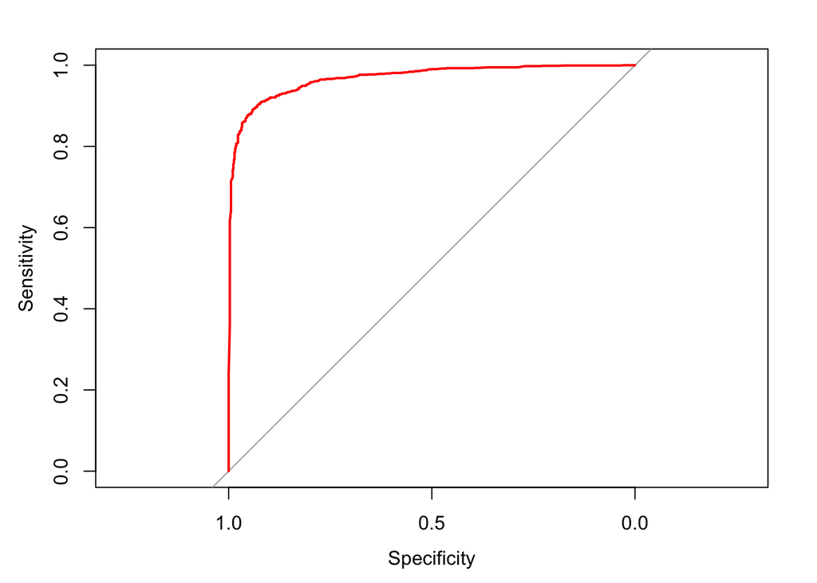

```r
plot(roc.forest,col="red",xlim=c(1,0),ylim=c(0,1))
```

```r
AUC1_forest = round(roc.forest$auc,4)
AUC1_forest
```

```
## [1] 0.9686
```

### 8) Analyzing with XGBoost Model

```r
resp.train_numeric <- as.numeric(as.factor(resp.train)) - 1
resp.test_numeric <- as.numeric(as.factor(resp.test)) - 1

train = xgb.DMatrix(data=as.matrix(pred.train),label=resp.train_numeric)
test = xgb.DMatrix(data=as.matrix(pred.test),label=resp.test_numeric)

set.seed(101)
xgb.cv.out = xgb.cv(params=list(objective="binary:logistic", eval_metric="error"),data=train,nrounds=30,nfold=5,verbose=0)

cat("The optimal number of trees is ",which.min(xgb.cv.out$evaluation_log$test_error_mean),"\n")
```

```
## The optimal number of trees is  30
```

```r
xgb.out = xgboost(train,nrounds=20,params=list(objective="binary:logistic"), eval_metric="error", verbose = 0)

pred_probs <- predict(xgb.out, newdata=test)
pred_classes <- ifelse(pred_probs > 0.5, "FALSE POSITIVE", "CONFIRMED")

MCR_xgboost = round(mean(pred_classes != resp.test),4)
CM_xgboost = table(pred_classes,resp.test)

MCR_xgboost
```

```
## [1] 0.0895
```

```r
CM_xgboost
```

```
##                 resp.test
## pred_classes     CONFIRMED FALSE POSITIVE
##   CONFIRMED            630            117
##   FALSE POSITIVE        67           1242
```

```r
roc.xgboost = roc(resp.test,pred_probs)
```

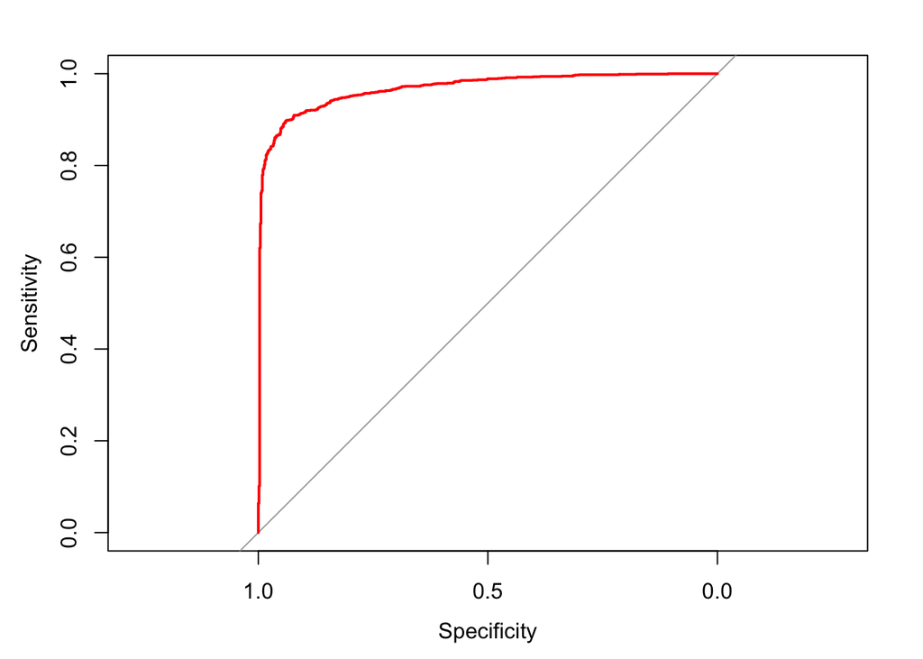

```r
plot(roc.xgboost,col="red",xlim=c(1,0),ylim=c(0,1))
```

```r
AUC_xgboost = round(roc.log$auc,4)
AUC_xgboost
```

```
## [1] 0.94
```

```r
optimal_threshold.xgboost <- coords(roc.xgboost, "best")$threshold
optimal_threshold.xgboost
```

```
## [1] 0.6494366
```

```r
xgb.out = xgboost(train,nrounds=20,params=list(objective="binary:logistic"), eval_metric="error", verbose = 0)

pred_probs1 <- predict(xgb.out, newdata=test)
pred_classes1 <- ifelse(pred_probs > 0.6919135, "FALSE POSITIVE", "CONFIRMED")

MCR1_xgboost = round(mean(pred_classes1 != resp.test),4)
CM1_xgboost = table(pred_classes1,resp.test)

MCR1_xgboost
```

```
## [1] 0.0934
```

```r
CM1_xgboost
```

```
##                 resp.test
## pred_classes1    CONFIRMED FALSE POSITIVE
##   CONFIRMED            659            154
##   FALSE POSITIVE        38           1205
```

```r
roc.xgboost1 = roc(resp.test,pred_probs1)
```

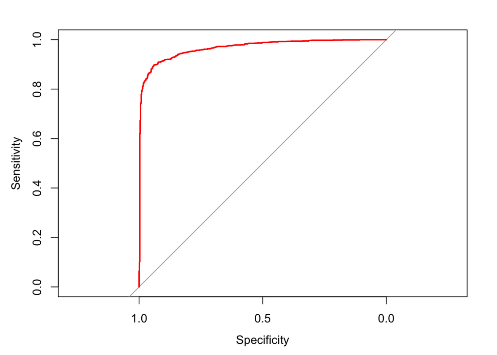

```r
plot(roc.xgboost1,col="red",xlim=c(1,0),ylim=c(0,1))
```

```r
AUC1_xgboost = round(roc.log$auc,4)
AUC1_xgboost
```

```
## [1] 0.94
```

### 9) Analyzing with K-Nearest Neighbours (kNN)

```r
k.max = 30
mcr.k = rep(NA, k.max)

for (kk in 1:k.max) {
  knn.out = knn.cv(train = pred.train, cl = resp.train, k = kk, algorithm = "brute", prob = TRUE)
  mcr.k[kk] = mean(knn.out != resp.train)
}

k.min = which.min(mcr.k)
cat("The optimal number of nearest neighbors is ", k.min, "\n")
```

```
## The optimal number of nearest neighbors is  5
```

```r
knn.out = knn(train = pred.train, test = pred.test, cl = resp.train, k = 9, algorithm = "brute", prob = TRUE)
MCR_knn = mean(knn.out != resp.test)
CM_knn = table(knn.out, resp.test)

MCR_knn
```

```
## [1] 0.1386187
```

```r
CM_knn
```

```
##                 resp.test
## knn.out          CONFIRMED FALSE POSITIVE
##   CONFIRMED            621            209
##   FALSE POSITIVE        76           1150
```

```r
knn.prob = attributes(knn.out)$prob
w = which(knn.out=="CONFIRMED")
knn.prob[w] = 1 - knn.prob[w]
```

```r
roc.knn=roc(resp.test, knn.prob)
```

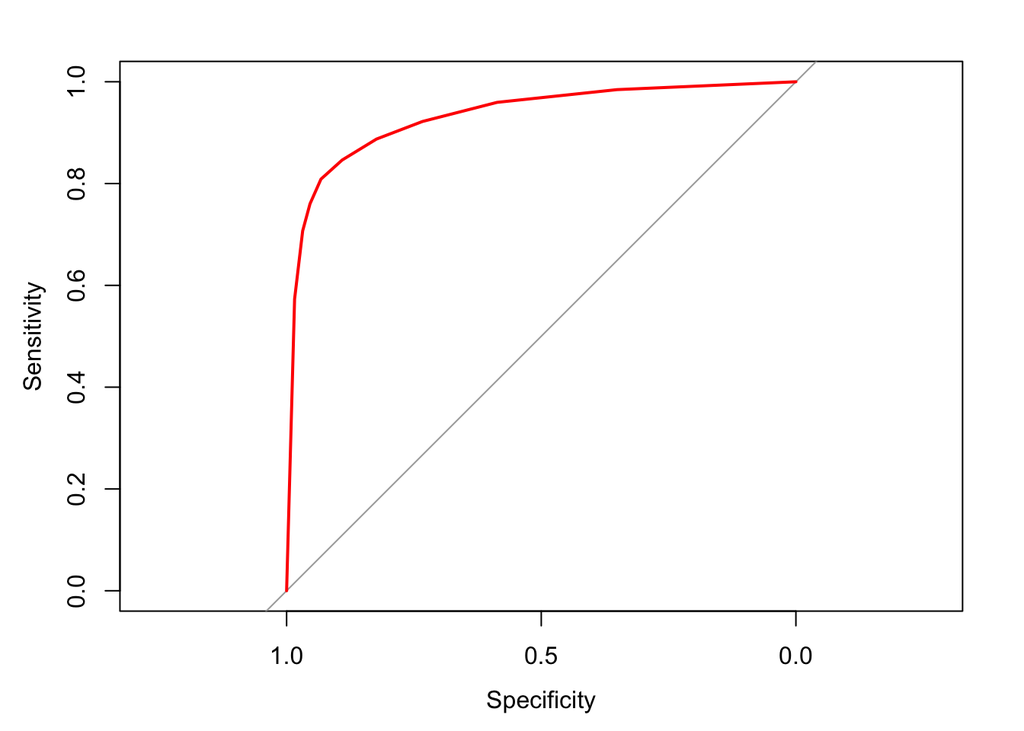

```r
plot(roc.knn,col="red",xlim=c(1,0),ylim=c(0,1))
```

```r
AUC_knn = round(roc.knn$auc,4)
AUC_knn
```

```
## [1] 0.9319
```

### 10) Summary and Choosing the Best Model

#### - Summarizing the performance of different models using metrics such as Misclassification Rate (MCR) and Area Under Curve (AUC)

The lower the MCR value and the higher the AUC value for the model, the better its performance is in classifying the exoplanets int he dataset.

```r
model_names <- c("Logistic Regression", "Regression Tree", "Random Forest", "XgBoost", "kNN")
mcr_values <- c(MCR_log1, MCR_tree, MCR1_forest, MCR1_xgboost, MCR_knn)
auc_values <- c(AUC1_log, AUC_tree, AUC1_forest, AUC1_xgboost, AUC_knn)

# Create a data frame
summary_table <- data.frame(ModelType = model_names, MCR = mcr_values, AUC = auc_values)

# Print the table
print(summary_table)
```

```
##             ModelType        MCR    AUC
## 1 Logistic Regression 0.13667315 0.9400
## 2     Regression Tree 0.12743191 0.9134
## 3       Random Forest 0.09776265 0.9686
## 4             XgBoost 0.09340000 0.9400
## 5                 kNN 0.13861868 0.9319
```

```r
lowest_mcr_row <- summary_table[which.min(round(summary_table$MCR,4)), ]
highest_auc_row <- summary_table[which.max(round(summary_table$AUC,4)), ]

print(lowest_mcr_row)
```

```
##   ModelType    MCR  AUC
## 4   XgBoost 0.0934 0.94
```

```r
print(highest_auc_row)
```

```
##       ModelType        MCR    AUC
## 3 Random Forest 0.09776265 0.9686
```

#### - Overlaying all the ROC curves on one plot

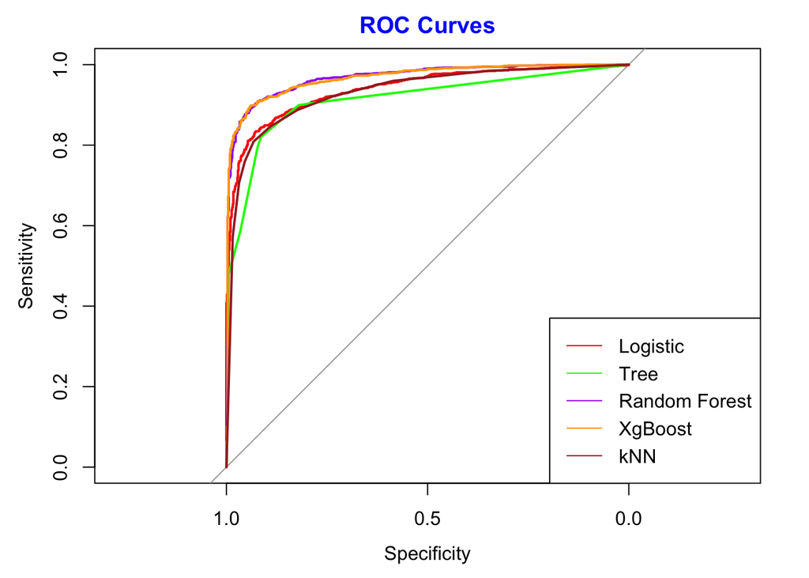

```r
roc_curve1 <- roc(resp.test_numeric, resp.prob.log)
roc_curve2 <- roc(resp.test_numeric, resp.pred.tree)
roc_curve3 <- roc(resp.test_numeric, out.pred)
roc_curve4 <- roc(resp.test_numeric, pred_probs1)
roc_curve5 <- roc(resp.test_numeric, knn.prob)
# Plot multiple ROC curves
plot.roc(roc_curve1, col = "red", main = "ROC Curves", col.main = "blue")
plot.roc(roc_curve2, col = "green", add = TRUE)
plot.roc(roc_curve3, col = "purple", add = TRUE)
plot.roc(roc_curve4, col = "orange", add = TRUE)
plot.roc(roc_curve5, col = "brown", add = TRUE)

legend("bottomright", legend = c("Logistic", "Tree", "Random Forest", "XgBoost", "kNN"), col = c("red", "green", "purple", "orange", "brown"), lty = 1)
```

From the plot above, we can see that our Random Forest Model and XgBoost are the highest - and in fact are almost overlapping in the plot.

### 11) Conclusion

In conclusion, we can see that Random Forest is the best model in classifying exoplanets as confirmed or false positive. The XgBoost Model is a close second, and is not too far off, in comparison to the Random Forest Model.

```r
cat("The optimal thereshold used for our best model (i.e. Random Forest) is ", optimal_threshold.forest, "\n")
```

```
## The optimal thereshold used for our best model (i.e. Random Forest) is  0.625
```

```r
cat("The misclassification rate for our best model (i.e. Random Forest) is ", MCR1_forest, "\n")
```

```
## The misclassification rate for our best model (i.e. Random Forest) is  0.09776265
```

```r
cat("The confusion matrix produced for our best model (i.e. Random Forest) is ", "\n")
```

```
## The confusion matrix produced for our best model (i.e. Random Forest) is
```

```r
CM1_forest
```

```
##                 resp.test
## resp.pred        CONFIRMED FALSE POSITIVE
##   FALSE POSITIVE        35           1193
##   CONFIRMED            662            166
```